# Analysis of airline on-time performance data for the year 2008

Liu_Xiaotian

2024-05-31

## 1. Introduction

This project analyzes airline on-time performance data for the year 2008. We aim to identify the best times of day, days of the week, and times of the year to minimize delays, uncover the primary factors contributing to delays and cancellations, and determine which flights are most frequently affected.

## 3. Analysis

### 3.1 Average Delays by Day of the Week

This section explores which days of the week experience the least and most delays, helping travelers choose the best day to fly.

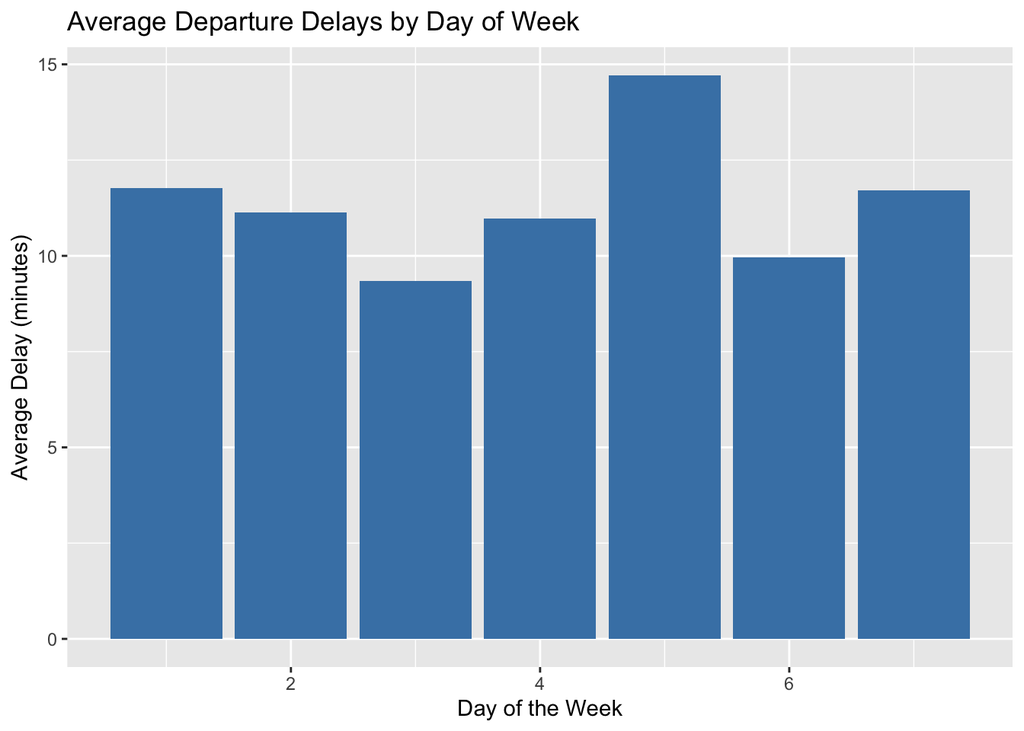

```r
ggplot(avg_delays_by_day, aes(x = day_of_week, y = avg_dep_delay)) +
  geom_col(fill = "steelblue") +
  labs(title = "Average Departure Delays by Day of Week", x = "Day of the Week", y = "Average Delay (minutes)")
```

### 3.2 Average Delays by Departure Time

We analyze how departure time affects flight delays, potentially aiding in choosing optimal flight times.

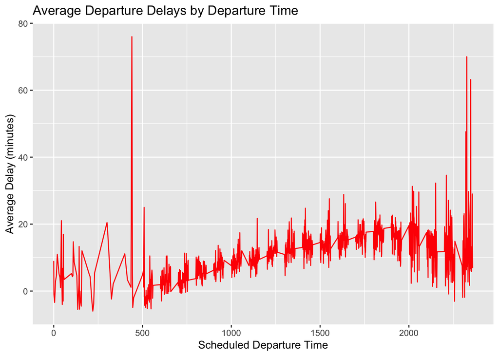

```r
ggplot(avg_delays_by_time, aes(x = dep_time, y = avg_dep_delay)) +
  geom_line(color = "red") +
  labs(title = "Average Departure Delays by Departure Time", x = "Scheduled Departure Time", y = "Average Delay (minutes)")
```

This chart shows the average departure delays across different scheduled departure times, plotted throughout the day from 0 to 2400 hours. Significant spikes can be observed at specific times, likely during peak hours such as early morning and late evening. These spikes may indicate congestion and operational delays at airports during these times.